# Iris Notebook 3 Clusters

1. Download and Install R
2. Install Packages

```r
library(datasets)
library(stats)
library(dbscan)
library(tidyverse)
```

3. Run the k-means algorithm (kmeans in R) on the iris dataset (iris was loaded above when you loaded the R datasets package). Of course, iris has a target attribute. It must be excluded from the clustering. The simplest way to do this is to create a copy of iris consisting of only the first 4 attributes.
1. Run k-means for k = 2, 3, 4, 5, 7, 9, 11.

```r
data(iris)
# remove target
glimpse(iris)
```

```
Observations: 150
Variables: 5
$ Sepal.Length <dbl> 5.1, 4.9, 4.7, 4.6, 5.0, 5.4, 4.6, 5.0, 4.4, 4.9, 5.4, 4.8, 4.8, 4.3,...
$ Sepal.Width  <dbl> 3.5, 3.0, 3.2, 3.1, 3.6, 3.9, 3.4, 3.4, 2.9, 3.1, 3.7, 3.4, 3.0, 3.0,...
$ Petal.Length <dbl> 1.4, 1.4, 1.3, 1.5, 1.4, 1.7, 1.4, 1.5, 1.4, 1.5, 1.5, 1.6, 1.4, 1.1,...
$ Petal.Width  <dbl> 0.2, 0.2, 0.2, 0.2, 0.2, 0.4, 0.3, 0.2, 0.2, 0.1, 0.2, 0.2, 0.1, 0.1,...
$ Species      <fct> setosa, setosa, setosa, setosa, setosa, setosa, setosa, setosa, setos...
```

```r
# identify target cluster and computed clusters
sets <- iris[1:4]
tc <- iris[5]
centers <- c(2, 3, 4, 5, 7, 9, 11)
iris.models <- lapply(centers, function(x) kmeans(sets,centers = x) )
```

2. For each value of k, report the size of the clusters and the F-measure (see the slide deck Basic Clustering for details; there is a link to it on our class schedule). Both size and cluster assignments are available in variables computed during k-means (see the documentation in the R stats package under kmeans). You will need the target values from the original iris dataset to compute the F-score. You may write a small program in R to do this (this is the preferred method as it will give you further experience with R and you will use that program again below) or export the data and compute elsewhere.

```r
## display each size and compute F-scores ##
# clean clusters as vectors
cluster.result <- lapply(1:length(centers), function(x) as.vector(iris.models[[x]]$cluster))
# check for null values
sapply(1:length(centers),
       function(x) iris.models[[x]]$cluster %>% is.null) %>% sum
```

```
[1] 0
```

```r
# grab all sizes
sizes <- sapply(1:length(centers), function(x) iris.models[[x]]$size)
names(sizes) <- centers
sizes # display of sizes
```

```
$`2`
[1] 53 97

$`3`
[1] 62 38 50

$`4`
[1] 62 28 38 22

$`5`
[1] 40 28 17 33 32

$`7`
[1] 22 21 33 21  7 17 29

$`9`
[1] 12 36 26 16  7 14  5 12 22

$`11`
 [1]  7 21  5  3 10 18 28 18 14 22  4
```

```r
# grab all f-measures
f1 <- function(x) {

  ## Function for a ##
  aa <- function(x,dataset = iris) {
    # ' Only works for iris
    # ' x stands for cluster results
    # ' dataset is predifined as iris.
    # ' calculating a (number of pairs of items that
    # ' belong to the same cluster in both CC and TC)


    check <- 0
    for(i in 1:nrow(dataset)){
      for (j in 1:nrow(dataset)){
        if (x[i]==x[j] & dataset$Species[i]==dataset$Species[j]) {
          check <- check + 1
        }
      }
    }
    ifelse(check >=1, check <- check+1, check)
  }




  ## Function for b ##
  bb <- function(x,dataset = iris) {
    # ' Only works for iris
    # ' x stands for cluster results
    # ' dataset is predifined as iris.
    # ' calculating b (number of pairs of items that
    # ' belong to different clusters in both CC and TC)

    check <- 0
    for(i in 1:nrow(dataset)){
      for (j in 1:nrow(dataset)){
        if (x[i]!=x[j] & dataset$Species[i]!=dataset$Species[j]){
          check <- check + 1
        }
      }
    }
    ifelse(check >=1, check <- check - 1, check)
  }
  ## Function for c ##
  cc <- function(x,dataset = iris) {
    check <- 0
    for(i in 1:nrow(dataset)){
      for (j in 1:nrow(dataset)){
        if (x[i]==x[j] & dataset$Species[i] != dataset$Species[j]){
          check <- check + 1
        }
      }
    }
    ifelse(check >=1, check <- check - 1, check)
  }
  ## Function for d ##
  dd <- function(x,dataset = iris) {
    check <- 0
    for(i in 1:nrow(dataset)){
      for (j in 1:nrow(dataset)){
        if (x[i]!=x[j] & dataset$Species[i]==dataset$Species[j]) {
          check <-check + 1
        }
      }
    }
    ifelse(check >=1, check <- check - 1, check)
  }
  ## precision calculation ##
  prec <- function(x) {
    aa(x) / (aa(x)+cc(x))
  }
  ##   recall calculation  ##
  rec <- function(x) {
    aa(x) / (aa(x) + dd(x))
  }
  ## f-measure calculation ##
  precision <- prec(x)
  recall <- rec(x)
  fmeasure <- (2 * precision * recall) / (precision + recall)

  # c(fmeasure,recall,precision)

  c("f-measure" = fmeasure, "recall" = recall, "precision" = precision)
}
ptm <- proc.time()
lapply(cluster.result, function(x) f1(x)[1]) %>%
  unlist -> fmez
proc.time() - ptm # 48 seconds.
```

```
   user  system elapsed
 38.666   1.441  40.311
```

```r
names(fmez) <- centers
fmez # F-measures
```

```
        2         3         4         5         7         9        11
0.7322244 0.8243066 0.7212578 0.6431711 0.6263697 0.5116063 0.5023410
```

3. Report the value of k that produces the highest F-score.

```r
which.max(fmez) # 3 clusters is the optimal K
```

```
3
2
```

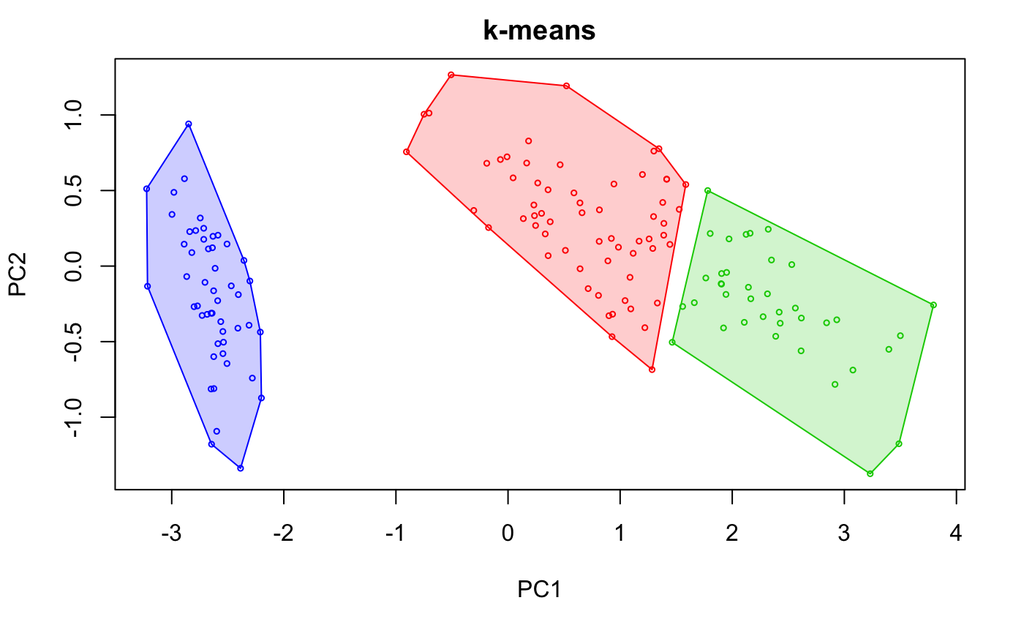

```r
hullplot(sets, iris.models[[2]], main = "k-means") # graphical representation of 3-means.
```

4. Comment on anything interesting about your experiment.

*Interesting how the k-means procedure allowed for automatic clustering with specified means. However, this method will not work with categorical datasets (use k-medioids). Another thing to recognize is how our criterion for f-measure is calculated on the proportion of false positives and false negatives. Though this took a while to calculate, it depicts 3 means as the best f-value.*

4. Run the hierarchical agglomerative clustering algorithm (hclust in R) on the iris dataset using complete link for the distance. Be mindful that hclust requires a distance matrix rather than a set of points as input.
1. Display and include in your report the result of hierarchical agglomerative clustering, including the dendrogram. Use the function plot() to graph the dendrogram.

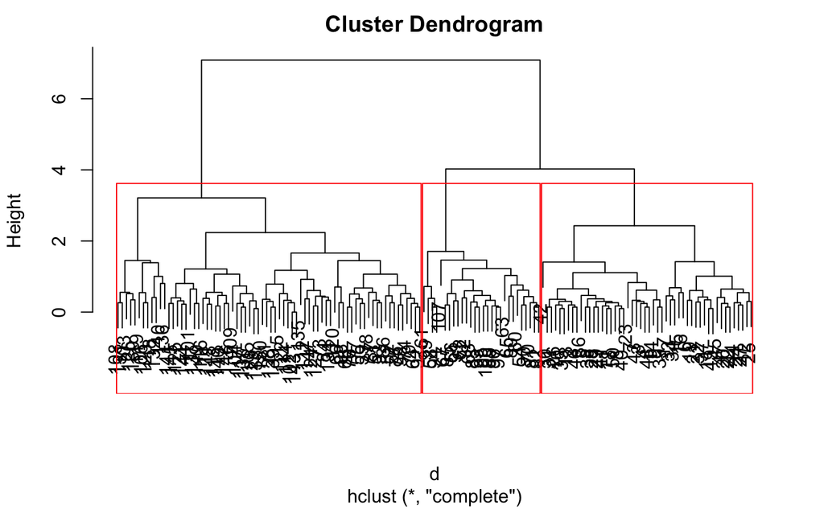

```r
d <- dist(sets) # By default, the complete linkage method is used. for distance matrix
fit <- hclust(d, method="complete")
plot(fit)
rect.hclust(fit,k=3) # we see 3 or 4 clusters in this dendogram
```

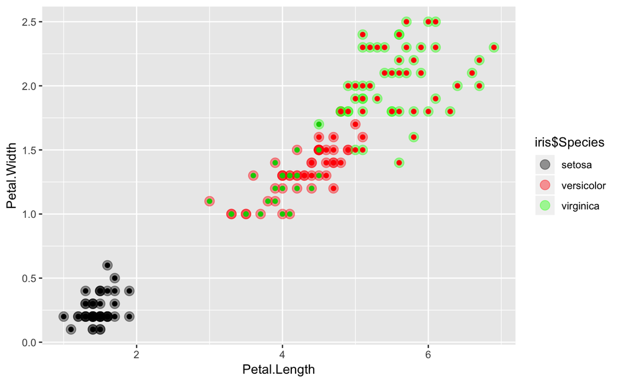

```r
clusterCut <- cutree(fit, 3)
# visual plot of 3 clusters.
ggplot(iris, aes(Petal.Length, Petal.Width, color = iris$Species)) +
  geom_point(alpha = 0.4, size = 3.5) + geom_point(col = clusterCut) +
  scale_color_manual(values = c('black', 'red', 'green'))
```

2. By looking at the display or using the values of clustering heights, select a threshold at which you feel the clustering would be optimal and justify your choice. (In principle, we would do this by computing some quality measure during the clustering process, but for simplicity, we are just eyeballing here).

*From the plot of dendrogram,we notice 3 or 4 clusters to be a ideal. This is because the clusters are tightly bound until the number of clusters gets to 4. However, because there is a slight jump from 3 to 4, we can reasonably conclude 3 clusters.*

3. How does the corresponding number and nature/composition of clusters compare with that obtained with k-means clustering above? Cluster composition (or assignments) is available in variables computed by the clustering algorithms.

```r
(50+28+38)/nrow(iris)
```

```
[1] 0.7733333
```

5. Run the density-based clustering algorithm (dbscan in R) on the iris dataset. Be mindful that dbscan requires a numeric matrix rather than a set of points as input.
1. Run dbscan for epsilon (eps in dbscan()) = 0.2, 0.3, 0.4, 0.5, 0.6, 0.8, and 1.0.

```r
iris.mat <- as.matrix(sets)
epsilons <- c(0.2, 0.3, 0.4, 0.5, 0.6, 0.8, 1.0)
dbscans <- lapply(epsilons,function(x) dbscan(iris.mat,eps = x))
```

2. For each value of eps, report the size of the clusters and the F-measure
3. Report the value of eps that produces the highest F-score.

```r
# grab all sizes
db.sizes <- sapply(1:length(epsilons), function(x) dbscans[[1]]$cluster %>% table)
names(db.sizes) <- epsilons
sizes
```

[output not shown]

```
$`2`
[1] 53 97

$`3`
[1] 62 38 50

$`4`
[1] 62 28 38 22

$`5`
[1] 40 28 17 33 32

$`7`
[1] 22 21 33 21  7 17 29

$`9`
[1] 12 36 26 16  7 14  5 12 22

$`11`
 [1]  7 21  5  3 10 18 28 18 14 22  4
```

```r
# grab all f-measures
lapply(1:length(epsilons),function(x) f1(dbscans[[x]]$cluster)[1]) %>%
  unlist -> db.fmez
max(db.fmez) # maximum F score given by epsilon 1.0
```

[output not shown]

```
[1] 0.7500625
```

4. comments:

*We notice here that our epsilon of 1 is ideal. This means that the distance of our points are spread by 1. We notice that our accuracy increases as we specify more correct distances between each of our points. However, even with epsilon of 1, we only get 2 clusters. We should probably be looking at higher epsilon values.*

5. How does the corresponding number and nature/composition of clusters compare with that obtained with k-means and hierarchical agglomerative clustering above? Cluster composition (or assignments) is available in variables computed by the clustering algorithms.

```r
## cluster size and composition comparison between dbscan, hclust, and kmeans
# kmeans clusters
kmeans
```

[output not shown]

```r
# heiarchial clusters
hclusts
```

[output not shown]

```r
# dbscan clusters
dbscans[[7]]$cluster %>% as.vector %>%
  factor -> dbscanss
sapply(1:3, function(x) sum(kmeans==x)) # size of k-means cluster # 1, 2, 3
```

```
[1] 62 38 50
```

```r
sapply(1:3, function(x) sum(hclusts==x)) # size of hcluster # 1, 2, 3
```

```
[1] 50 72 28
```

```r
sapply(1:2, function(x) sum(dbscanss==x)) # size of dbscan cluster 1, 2
```

```
[1]  50 100
```

```r
lapply(1:3, function(x) which(kmeans==x)) # Datapoints of each kmeans cluster 1,2,3
```

```
[[1]]
 [1]  51  52  54  55  56  57  58  59  60  61  62  63  64  65  66  67  68  69  70  71  72  73
[23]  74  75  76  77  79  80  81  82  83  84  85  86  87  88  89  90  91  92  93  94  95  96
[45]  97  98  99 100 102 107 114 115 120 122 124 127 128 134 139 143 147 150

[[2]]
 [1]  53  78 101 103 104 105 106 108 109 110 111 112 113 116 117 118 119 121 123 125 126 129
[23] 130 131 132 133 135 136 137 138 140 141 142 144 145 146 148 149

[[3]]
 [1]  1  2  3  4  5  6  7  8  9 10 11 12 13 14 15 16 17 18 19 20 21 22 23 24 25 26 27 28 29 30
[31] 31 32 33 34 35 36 37 38 39 40 41 42 43 44 45 46 47 48 49 50
```

```r
lapply(1:3, function(x) which(hclusts==x)) # Datapoints of each hcluster 1,2,3
```

```
[[1]]
 [1]  1  2  3  4  5  6  7  8  9 10 11 12 13 14 15 16 17 18 19 20 21 22 23 24 25 26 27 28 29 30
[31] 31 32 33 34 35 36 37 38 39 40 41 42 43 44 45 46 47 48 49 50

[[2]]
 [1]  51  52  53  55  57  59  64  66  69  71  73  74  75  76  77  78  79  84  86  87  88  92
[23]  98 101 102 103 104 105 106 108 109 110 111 112 113 114 115 116 117 118 119 120 121 122
[45] 123 124 125 126 127 128 129 130 131 132 133 134 135 136 137 138 139 140 141 142 143 144
[67] 145 146 147 148 149 150

[[3]]
 [1]  54  56  58  60  61  62  63  65  67  68  70  72  80  81  82  83  85  89  90  91  93  94
[23]  95  96  97  99 100 107
```

```r
lapply(1:2, function(x) which(dbscanss==x)) # Datapoints of each dbscan cluster 1,22
```

```
[[1]]
 [1]  1  2  3  4  5  6  7  8  9 10 11 12 13 14 15 16 17 18 19 20 21 22 23 24 25 26 27 28 29 30
[31] 31 32 33 34 35 36 37 38 39 40 41 42 43 44 45 46 47 48 49 50

[[2]]
  [1]  51  52  53  54  55  56  57  58  59  60  61  62  63  64  65  66  67  68  69  70  71  72
 [23]  73  74  75  76  77  78  79  80  81  82  83  84  85  86  87  88  89  90  91  92  93  94
 [45]  95  96  97  98  99 100 101 102 103 104 105 106 107 108 109 110 111 112 113 114 115 116
 [67] 117 118 119 120 121 122 123 124 125 126 127 128 129 130 131 132 133 134 135 136 137 138
 [89] 139 140 141 142 143 144 145 146 147 148 149 150
```

*To compare the cluster compositions of dbscan with the other two would be unfair. This is because we are comparing 2 clusters against 3. We also notice different compositions of clusters. The optimal method seemed to be with the k-means.*

6. Consider the swiss dataset (swiss was loaded above when you loaded the R datasets package). Use a clustering algorithm, whichever of the three studied here seems to make most sense, to produce a list of the Swiss cities predominantly protestant and those predominantly catholic. You may produce a graph or simply a list of the cities.

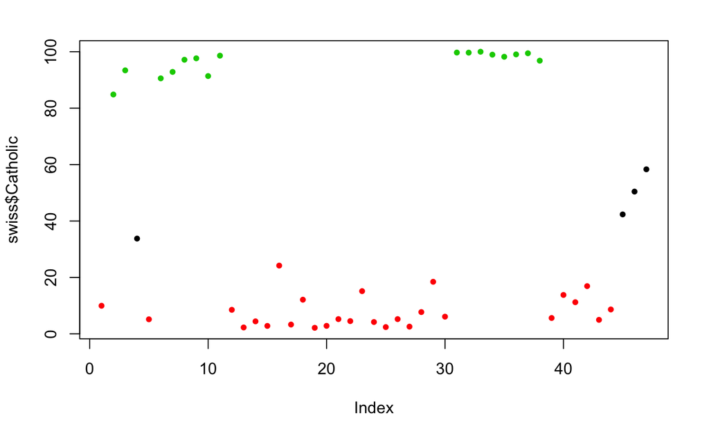